# South Dade Conveyance System Environmental Information

Updated: December 09, 2020

### [Source Code](https://github.com/owper-tech/SouthDade_WQ)

- GitHub repo https://github.com/owper-tech/SouthDade_WQ

*Please note this analysis is for informational purposes only and subject to change.*

Data and information presented herein is purely for information purposes and subject to change. This information is intended to provide a retrospective look at water quality (i.e. total phosphorus) and water quantity within the southern Miami-Dade County region which spans Everglades National Park eastern boundary.

Major structural elements of the South Dade Conveyance System were constructed in the period between 1974 and 1979 to improve water supply capabilities to the southern portions of Miami-Dade County. Later structures, detention basins and project features were constructed as part of the [Modified Waters Delivery to Everglades National Park](https://www.nps.gov/ever/learn/nature/modwater.htm) (Mod Waters) and the [C-111](http://www.saj.usace.army.mil/Missions/Environmental/Ecosystem-Restoration/C-111-South-Dade-Project/) Comprehensive Everglades Restoration Plan (CERP) project.

[interactive chart not shown]

# Hydrologic Information

Provided in this section are period of record (POR) discharge data and associated metrics of available data in the South Florida Water Management Districts [DBHYDRO](http://my.sfwmd.gov/dbhydroplsql/show_dbkey_info.main_menu). All structure DBKEYs used to construct these discharge time-series can be downloaded below.

Below are a series of plots for each structure with accessible/available data. Only positive flows were used in this analysis. Reverse flow has been observed at some structures The three plots are flow-duration curves using daily data for the entire POR for any given structure (left), daily discharge volume (middle) and total discharge volume based on the Florida Water Year (right). The lower flow-duration limit (20% Exceedance) for each structure has been identified where applicable. All hydrologic data is presented in m<sup>3</sup> d<sup>-1</sup> or m<sup>3</sup> WY<sup>-1</sup>, to convert from m<sup>3</sup> to acre-feet, multiply values by 0.000810714.

## S331

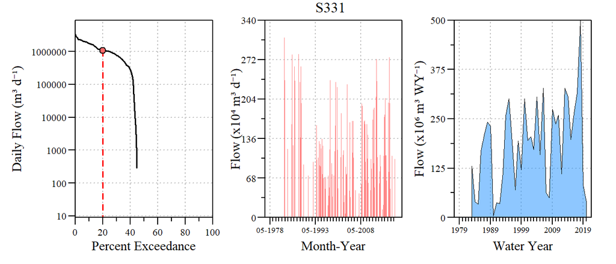

Daily Discharge Data Summary for the Period of Record (Units:m<sup>3</sup> d<sup>-1</sup>)

| SITE | Min | Q1 | Median | Q3 | Max |
| --- | --- | --- | --- | --- | --- |
| S331 | 0 | 0 | 0 | 1010126 | 3387241 |

Daily Discharge Data Summary for the last 10-WYs (May 2009 - April 2020; Units:m<sup>3</sup> d<sup>-1</sup>)

| SITE | Min | Q1 | Median | Q3 | Max |
| --- | --- | --- | --- | --- | --- |
| S331 | 0 | 0 | 71611.4 | 1130467 | 2993122 |

Water Year Discharge Data Summary for the Period of Record (Units:m<sup>3</sup> WY<sup>-1</sup>)

| SITE | Min | Q1 | Median | Q3 | Max |
| --- | --- | --- | --- | --- | --- |
| S331 | 3247248 | 88365069 | 194768234 | 263284236 | 498337739 |

Water Year Discharge Data Summary for the last 10-WYs (May 2009 - April 2020; Units:m<sup>3</sup> WY<sup>-1</sup>)

| SITE | Min | Q1 | Median | Q3 | Max |
| --- | --- | --- | --- | --- | --- |
| S331 | 39743028 | 175631054 | 262065551 | 308224363 | 498337739 |

## S173

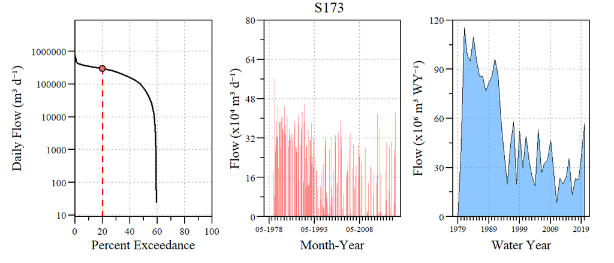

Daily Discharge Data Summary for the Period of Record (Units:m<sup>3</sup> d<sup>-1</sup>)

| SITE | Min | Q1 | Median | Q3 | Max |
| --- | --- | --- | --- | --- | --- |
| S173 | 0 | 0 | 75917.38 | 272426.7 | 779284.7 |

Daily Discharge Data Summary for the last 10-WYs (May 2009 - April 2020; Units:m<sup>3</sup> d<sup>-1</sup>)

| SITE | Min | Q1 | Median | Q3 | Max |
| --- | --- | --- | --- | --- | --- |
| S173 | 0 | 0 | 0 | 149131.3 | 652454 |

Water Year Discharge Data Summary for the Period of Record (Units:m<sup>3</sup> WY<sup>-1</sup>)

| SITE | Min | Q1 | Median | Q3 | Max |
| --- | --- | --- | --- | --- | --- |
| S173 | 0 | 24206719 | 40743117 | 80695395 | 115510577 |

Water Year Discharge Data Summary for the last 10-WYs (May 2009 - April 2020; Units:m<sup>3</sup> WY<sup>-1</sup>)

| SITE | Min | Q1 | Median | Q3 | Max |
| --- | --- | --- | --- | --- | --- |
| S173 | 8378656 | 21779865 | 23672949 | 35918431 | 56641972 |

## S357

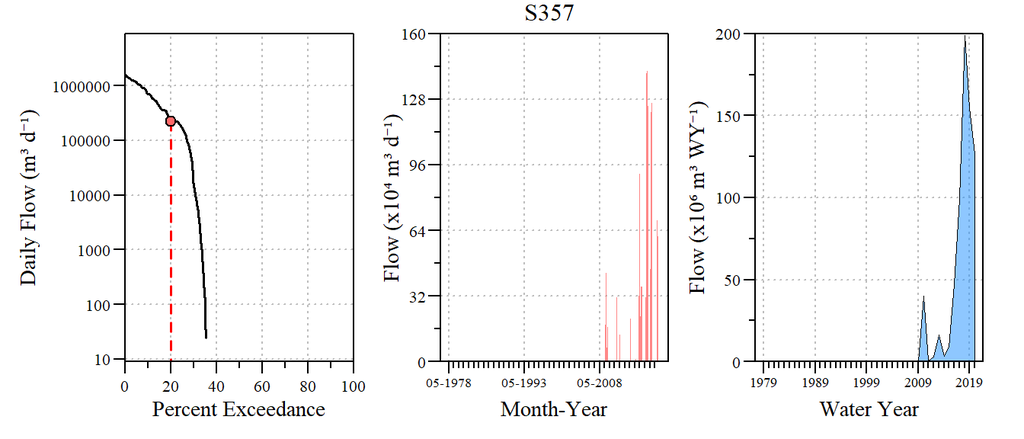

Daily Discharge Data Summary for the Period of Record (Units:m<sup>3</sup> d<sup>-1</sup>)

| SITE | Min | Q1 | Median | Q3 | Max |
| --- | --- | --- | --- | --- | --- |
| S357 | 0 | 0 | 0 | 168385.9 | 1598620 |

Daily Discharge Data Summary for the last 10-WYs (May 2009 - April 2020; Units:m<sup>3</sup> d<sup>-1</sup>)

| SITE | Min | Q1 | Median | Q3 | Max |
| --- | --- | --- | --- | --- | --- |
| S357 | 0 | 0 | 0 | 168385.9 | 1598620 |

Water Year Discharge Data Summary for the Period of Record (Units:m<sup>3</sup> WY<sup>-1</sup>)

| SITE | Min | Q1 | Median | Q3 | Max |
| --- | --- | --- | --- | --- | --- |
| S357 | 256254.8 | 3034469 | 28197874 | 105985534 | 199038800 |

Water Year Discharge Data Summary for the last 10-WYs (May 2009 - April 2020; Units:m<sup>3</sup> WY<sup>-1</sup>)

| SITE | Min | Q1 | Median | Q3 | Max |
| --- | --- | --- | --- | --- | --- |
| S357 | 256254.8 | 3034469 | 28197874 | 105985534 | 199038800 |

## S332B

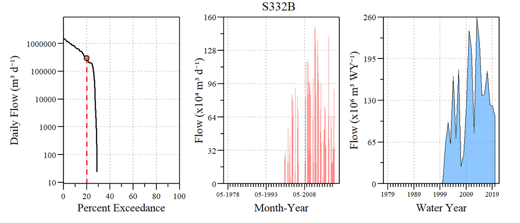

Daily Discharge Data Summary for the Period of Record (Units:m<sup>3</sup> d<sup>-1</sup>)

| SITE | Min | Q1 | Median | Q3 | Max |
| --- | --- | --- | --- | --- | --- |
| S332B | 0 | 0 | 0 | 151614.6 | 1557958 |

Daily Discharge Data Summary for the last 10-WYs (May 2009 - April 2020; Units:m<sup>3</sup> d<sup>-1</sup>)

| SITE | Min | Q1 | Median | Q3 | Max |
| --- | --- | --- | --- | --- | --- |
| S332B | 0 | 0 | 275338.1 | 840889.5 | 1535694 |

Water Year Discharge Data Summary for the Period of Record (Units:m<sup>3</sup> WY<sup>-1</sup>)

| SITE | Min | Q1 | Median | Q3 | Max |
| --- | --- | --- | --- | --- | --- |
| S332B | 0 | 0 | 1001875 | 122073308 | 259223641 |

Water Year Discharge Data Summary for the last 10-WYs (May 2009 - April 2020; Units:m<sup>3</sup> WY<sup>-1</sup>)

| SITE | Min | Q1 | Median | Q3 | Max |
| --- | --- | --- | --- | --- | --- |
| S332B | 79956167 | 122073308 | 138441650 | 212855891 | 259223641 |

## S332C

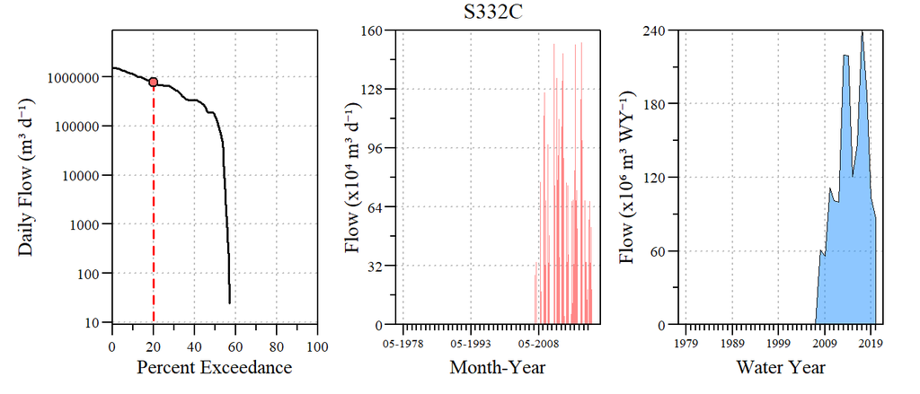

Daily Discharge Data Summary for the Period of Record (Units:m<sup>3</sup> d<sup>-1</sup>)

| SITE | Min | Q1 | Median | Q3 | Max |
| --- | --- | --- | --- | --- | --- |
| S332C | 0 | 0 | 156776.8 | 674448.7 | 1559866 |

Daily Discharge Data Summary for the last 10-WYs (May 2009 - April 2020; Units:m<sup>3</sup> d<sup>-1</sup>)

| SITE | Min | Q1 | Median | Q3 | Max |
| --- | --- | --- | --- | --- | --- |
| S332C | 0 | 0 | 190417.3 | 681005.5 | 1559866 |

Water Year Discharge Data Summary for the Period of Record (Units:m<sup>3</sup> WY<sup>-1</sup>)

| SITE | Min | Q1 | Median | Q3 | Max |
| --- | --- | --- | --- | --- | --- |
| S332C | 638728.6 | 90031392 | 107943672 | 177726312 | 242932965 |

Water Year Discharge Data Summary for the last 10-WYs (May 2009 - April 2020; Units:m<sup>3</sup> WY<sup>-1</sup>)

| SITE | Min | Q1 | Median | Q3 | Max |
| --- | --- | --- | --- | --- | --- |
| S332C | 55784740 | 100885197 | 116278962 | 195726571 | 242932965 |

## S174

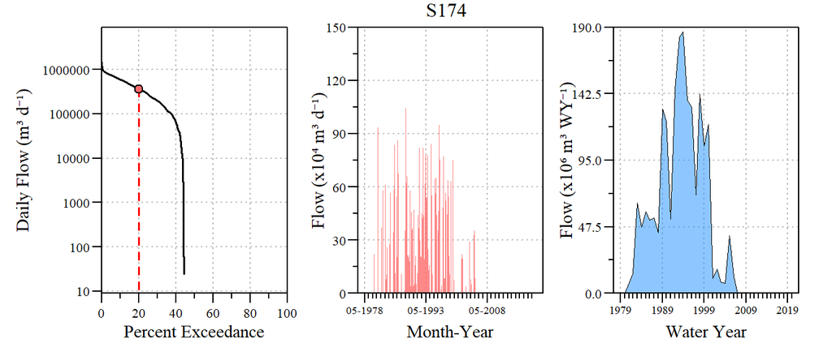

Daily Discharge Data Summary for the Period of Record (Units:m<sup>3</sup> d<sup>-1</sup>)

| SITE | Min | Q1 | Median | Q3 | Max |
| --- | --- | --- | --- | --- | --- |
| S174 | 0 | 0 | 0 | 274408.4 | 1506971 |

Daily Discharge Data Summary for the last 10-WYs (May 2009 - April 2020; Units:m<sup>3</sup> d<sup>-1</sup>)

| SITE | Min | Q1 | Median | Q3 | Max |
| --- | --- | --- | --- | --- | --- |
| S174 | 0 | 0 | 0 | 0 | 244.658 |

Water Year Discharge Data Summary for the Period of Record (Units:m<sup>3</sup> WY<sup>-1</sup>)

| SITE | Min | Q1 | Median | Q3 | Max |
| --- | --- | --- | --- | --- | --- |
| S174 | 0 | 7711180 | 47503654 | 120563523 | 186820482 |

Water Year Discharge Data Summary for the last 10-WYs (May 2009 - April 2020; Units:m<sup>3</sup> WY<sup>-1</sup>)

| SITE | Min | Q1 | Median | Q3 | Max |
| --- | --- | --- | --- | --- | --- |
| S174 | 0 | 0 | 0 | 122.329 | 244.658 |

## S332D

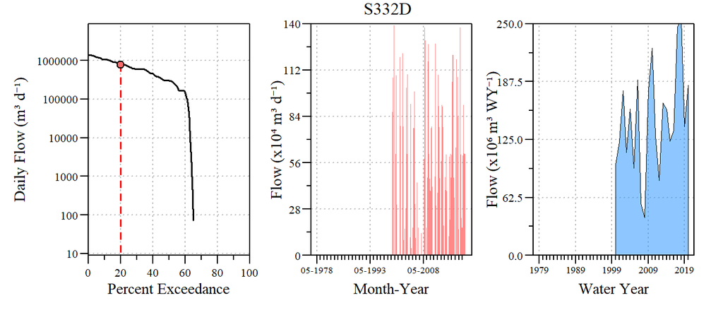

Daily Discharge Data Summary for the Period of Record (Units:m<sup>3</sup> d<sup>-1</sup>)

| SITE | Min | Q1 | Median | Q3 | Max |
| --- | --- | --- | --- | --- | --- |
| S332D | 0 | 0 | 302641.9 | 700174.5 | 1398392 |

Daily Discharge Data Summary for the last 10-WYs (May 2009 - April 2020; Units:m<sup>3</sup> d<sup>-1</sup>)

| SITE | Min | Q1 | Median | Q3 | Max |
| --- | --- | --- | --- | --- | --- |
| S332D | 0 | 0 | 385850.1 | 734683.5 | 1391810 |

Water Year Discharge Data Summary for the Period of Record (Units:m<sup>3</sup> WY<sup>-1</sup>)

| SITE | Min | Q1 | Median | Q3 | Max |
| --- | --- | --- | --- | --- | --- |
| S332D | 40511255 | 111306815 | 139077161 | 178228704 | 254456822 |

Water Year Discharge Data Summary for the last 10-WYs (May 2009 - April 2020; Units:m<sup>3</sup> WY<sup>-1</sup>)

| SITE | Min | Q1 | Median | Q3 | Max |
| --- | --- | --- | --- | --- | --- |
| S332D | 80855114 | 133630597 | 160806621 | 193688845 | 254456822 |

## S332DX1

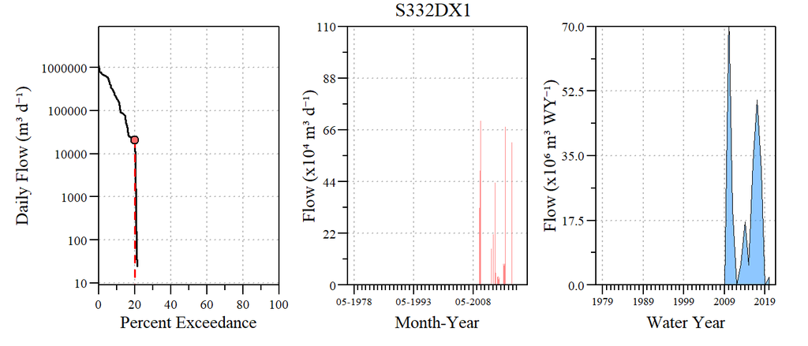

Daily Discharge Data Summary for the Period of Record (Units:m<sup>3</sup> d<sup>-1</sup>)

| SITE | Min | Q1 | Median | Q3 | Max |
| --- | --- | --- | --- | --- | --- |
| S332DX1 | 0 | 0 | 0 | 0 | 1094502 |

Daily Discharge Data Summary for the last 10-WYs (May 2009 - April 2020; Units:m<sup>3</sup> d<sup>-1</sup>)

| SITE | Min | Q1 | Median | Q3 | Max |
| --- | --- | --- | --- | --- | --- |
| S332DX1 | 0 | 0 | 0 | 0 | 1094502 |

Water Year Discharge Data Summary for the Period of Record (Units:m<sup>3</sup> WY<sup>-1</sup>)

| SITE | Min | Q1 | Median | Q3 | Max |
| --- | --- | --- | --- | --- | --- |
| S332DX1 | 0 | 1654579 | 11476454 | 31486341 | 73121255 |

Water Year Discharge Data Summary for the last 10-WYs (May 2009 - April 2020; Units:m<sup>3</sup> WY<sup>-1</sup>)

| SITE | Min | Q1 | Median | Q3 | Max |
| --- | --- | --- | --- | --- | --- |
| S332DX1 | 0 | 1654579 | 11476454 | 31486341 | 73121255 |

## S328

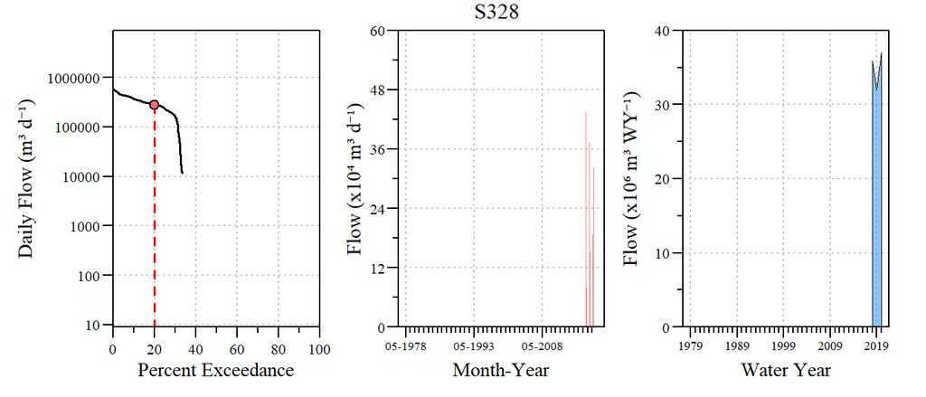

Daily Discharge Data Summary for the Period of Record (Units:m<sup>3</sup> d<sup>-1</sup>)

| SITE | Min | Q1 | Median | Q3 | Max |
| --- | --- | --- | --- | --- | --- |
| S328 | 0 | 0 | 0 | 231519.9 | 585393.2 |

Daily Discharge Data Summary for the last 10-WYs (May 2009 - April 2020; Units:m<sup>3</sup> d<sup>-1</sup>)

| SITE | Min | Q1 | Median | Q3 | Max |
| --- | --- | --- | --- | --- | --- |
| S328 | 0 | 0 | 0 | 231519.9 | 585393.2 |

Water Year Discharge Data Summary for the Period of Record (Units:m<sup>3</sup> WY<sup>-1</sup>)

| SITE | Min | Q1 | Median | Q3 | Max |
| --- | --- | --- | --- | --- | --- |
| S328 | 32007970 | 33950212 | 35892454 | 36447754 | 37003055 |

Water Year Discharge Data Summary for the last 10-WYs (May 2009 - April 2020; Units:m<sup>3</sup> WY<sup>-1</sup>)

| SITE | Min | Q1 | Median | Q3 | Max |
| --- | --- | --- | --- | --- | --- |
| S328 | 32007970 | 33950212 | 35892454 | 36447754 | 37003055 |

## S332

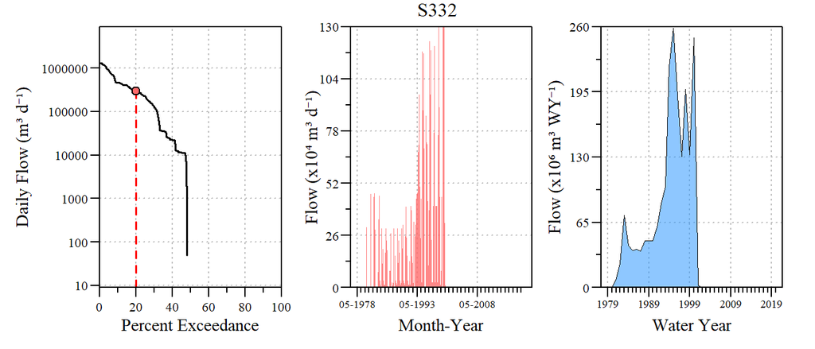

Daily Discharge Data Summary for the Period of Record (Units:m<sup>3</sup> d<sup>-1</sup>)

| SITE | Min | Q1 | Median | Q3 | Max |
| --- | --- | --- | --- | --- | --- |
| S332 | 0 | 0 | 0 | 229244.5 | 1319098 |

Daily Discharge Data Summary for the last 10-WYs (May 2009 - April 2020; Units:m<sup>3</sup> d<sup>-1</sup>)

| SITE | Min | Q1 | Median | Q3 | Max |
| --- | --- | --- | --- | --- | --- |
| S332 | 0 | 0 | 0 | 0 | 1272.222 |

Water Year Discharge Data Summary for the Period of Record (Units:m<sup>3</sup> WY<sup>-1</sup>)

| SITE | Min | Q1 | Median | Q3 | Max |
| --- | --- | --- | --- | --- | --- |
| S332 | 0 | 36.6987 | 30470197 | 74940275 | 258589560 |

Water Year Discharge Data Summary for the last 10-WYs (May 2009 - April 2020; Units:m<sup>3</sup> WY<sup>-1</sup>)

| SITE | Min | Q1 | Median | Q3 | Max |
| --- | --- | --- | --- | --- | --- |
| S332 | 0 | 0 | 0 | 0 | 1272.222 |

## S176

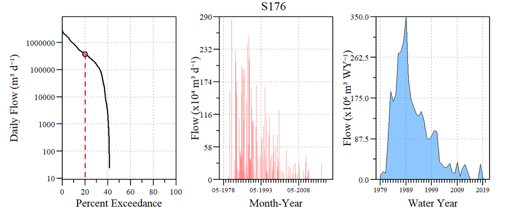

Daily Discharge Data Summary for the Period of Record (Units:m<sup>3</sup> d<sup>-1</sup>)

| SITE | Min | Q1 | Median | Q3 | Max |
| --- | --- | --- | --- | --- | --- |
| S176 | 0 | 0 | 0 | 257710.5 | 2903479 |

Daily Discharge Data Summary for the last 10-WYs (May 2009 - April 2020; Units:m<sup>3</sup> d<sup>-1</sup>)

| SITE | Min | Q1 | Median | Q3 | Max |
| --- | --- | --- | --- | --- | --- |
| S176 | 0 | 0 | 0 | 0 | 1186738 |

Water Year Discharge Data Summary for the Period of Record (Units:m<sup>3</sup> WY<sup>-1</sup>)

| SITE | Min | Q1 | Median | Q3 | Max |
| --- | --- | --- | --- | --- | --- |
| S176 | 0 | 16433537 | 37969209 | 144886859 | 350523816 |

Water Year Discharge Data Summary for the last 10-WYs (May 2009 - April 2020; Units:m<sup>3</sup> WY<sup>-1</sup>)

| SITE | Min | Q1 | Median | Q3 | Max |
| --- | --- | --- | --- | --- | --- |
| S176 | 0 | 0 | 4649444 | 26271584 | 37756821 |

## S200

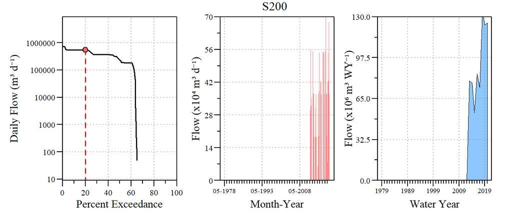

Daily Discharge Data Summary for the Period of Record (Units:m<sup>3</sup> d<sup>-1</sup>)

| SITE | Min | Q1 | Median | Q3 | Max |
| --- | --- | --- | --- | --- | --- |
| S200 | 0 | 0 | 232669.8 | 430261.7 | 736836.5 |

Daily Discharge Data Summary for the last 10-WYs (May 2009 - April 2020; Units:m<sup>3</sup> d<sup>-1</sup>)

| SITE | Min | Q1 | Median | Q3 | Max |
| --- | --- | --- | --- | --- | --- |
| S200 | 0 | 0 | 232669.8 | 430261.7 | 736836.5 |

Water Year Discharge Data Summary for the Period of Record (Units:m<sup>3</sup> WY<sup>-1</sup>)

| SITE | Min | Q1 | Median | Q3 | Max |
| --- | --- | --- | --- | --- | --- |
| S200 | 0 | 73889040 | 79131865 | 123614140 | 133488194 |

Water Year Discharge Data Summary for the last 10-WYs (May 2009 - April 2020; Units:m<sup>3</sup> WY<sup>-1</sup>)

| SITE | Min | Q1 | Median | Q3 | Max |
| --- | --- | --- | --- | --- | --- |
| S200 | 0 | 73889040 | 79131865 | 123614140 | 133488194 |

## S332

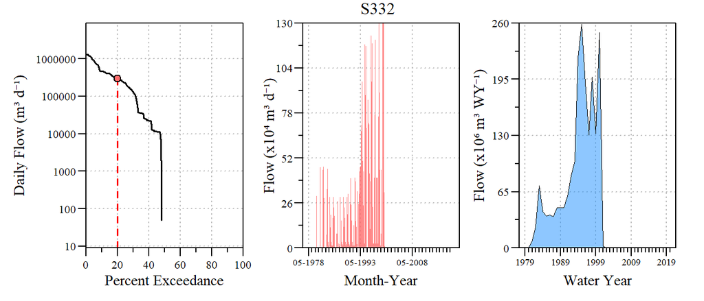

Daily Discharge Data Summary for the Period of Record (Units:m<sup>3</sup> d<sup>-1</sup>)

| SITE | Min | Q1 | Median | Q3 | Max |
| --- | --- | --- | --- | --- | --- |
| S332 | 0 | 0 | 0 | 229244.5 | 1319098 |

Daily Discharge Data Summary for the last 10-WYs (May 2009 - April 2020; Units:m<sup>3</sup> d<sup>-1</sup>)

| SITE | Min | Q1 | Median | Q3 | Max |
| --- | --- | --- | --- | --- | --- |
| S332 | 0 | 0 | 0 | 0 | 1272.222 |

Water Year Discharge Data Summary for the Period of Record (Units:m<sup>3</sup> WY<sup>-1</sup>)

| SITE | Min | Q1 | Median | Q3 | Max |
| --- | --- | --- | --- | --- | --- |
| S332 | 0 | 36.6987 | 30470197 | 74940275 | 258589560 |

Water Year Discharge Data Summary for the last 10-WYs (May 2009 - April 2020; Units:m<sup>3</sup> WY<sup>-1</sup>)

| SITE | Min | Q1 | Median | Q3 | Max |
| --- | --- | --- | --- | --- | --- |
| S332 | 0 | 0 | 0 | 0 | 1272.222 |

## S175

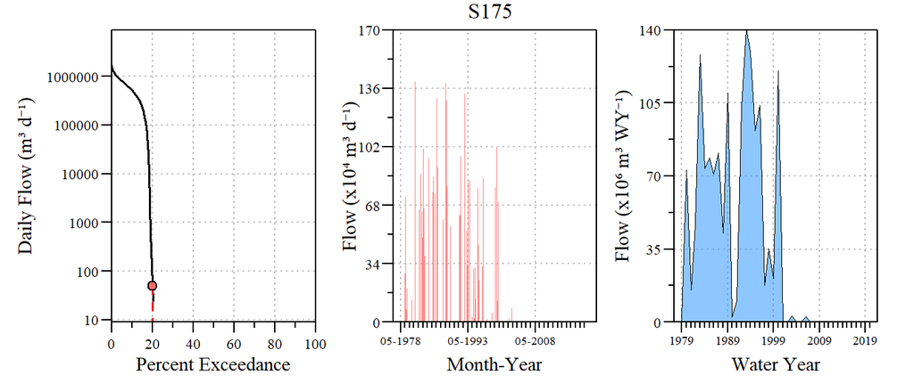

Daily Discharge Data Summary for the Period of Record (Units:m<sup>3</sup> d<sup>-1</sup>)

| SITE | Min | Q1 | Median | Q3 | Max |
| --- | --- | --- | --- | --- | --- |
| S175 | 0 | 0 | 0 | 0 | 1695235 |

Daily Discharge Data Summary for the last 10-WYs (May 2009 - April 2020; Units:m<sup>3</sup> d<sup>-1</sup>)

| SITE | Min | Q1 | Median | Q3 | Max |
| --- | --- | --- | --- | --- | --- |
| S175 | 0 | 0 | 0 | 0 | 33738.34 |

Water Year Discharge Data Summary for the Period of Record (Units:m<sup>3</sup> WY<sup>-1</sup>)

| SITE | Min | Q1 | Median | Q3 | Max |
| --- | --- | --- | --- | --- | --- |
| S175 | 220.1922 | 7816.823 | 10183473 | 76156494 | 140444212 |

Water Year Discharge Data Summary for the last 10-WYs (May 2009 - April 2020; Units:m<sup>3</sup> WY<sup>-1</sup>)

| SITE | Min | Q1 | Median | Q3 | Max |
| --- | --- | --- | --- | --- | --- |
| S175 | 220.1922 | 905.2346 | 2104.059 | 4648.502 | 51524.97 |

## S199

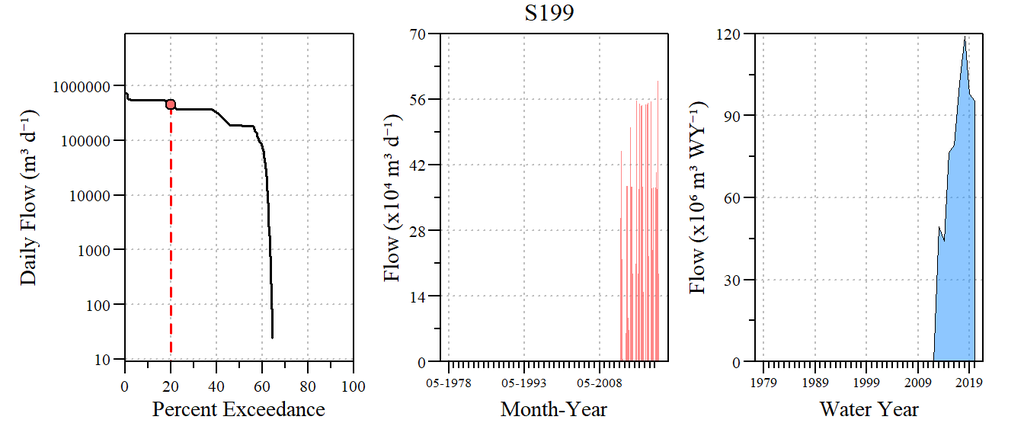

Daily Discharge Data Summary for the Period of Record (Units:m<sup>3</sup> d<sup>-1</sup>)

| SITE | Min | Q1 | Median | Q3 | Max |
| --- | --- | --- | --- | --- | --- |
| S199 | 0 | 0 | 187187.8 | 372730.3 | 735955.7 |

Daily Discharge Data Summary for the last 10-WYs (May 2009 - April 2020; Units:m<sup>3</sup> d<sup>-1</sup>)

| SITE | Min | Q1 | Median | Q3 | Max |
| --- | --- | --- | --- | --- | --- |
| S199 | 0 | 0 | 187187.8 | 372730.3 | 735955.7 |

Water Year Discharge Data Summary for the Period of Record (Units:m<sup>3</sup> WY<sup>-1</sup>)

| SITE | Min | Q1 | Median | Q3 | Max |
| --- | --- | --- | --- | --- | --- |
| S199 | 0 | 49271552 | 79242769 | 98016160 | 119015107 |

Water Year Discharge Data Summary for the last 10-WYs (May 2009 - April 2020; Units:m<sup>3</sup> WY<sup>-1</sup>)

| SITE | Min | Q1 | Median | Q3 | Max |
| --- | --- | --- | --- | --- | --- |
| S199 | 0 | 49271552 | 79242769 | 98016160 | 119015107 |

## S177

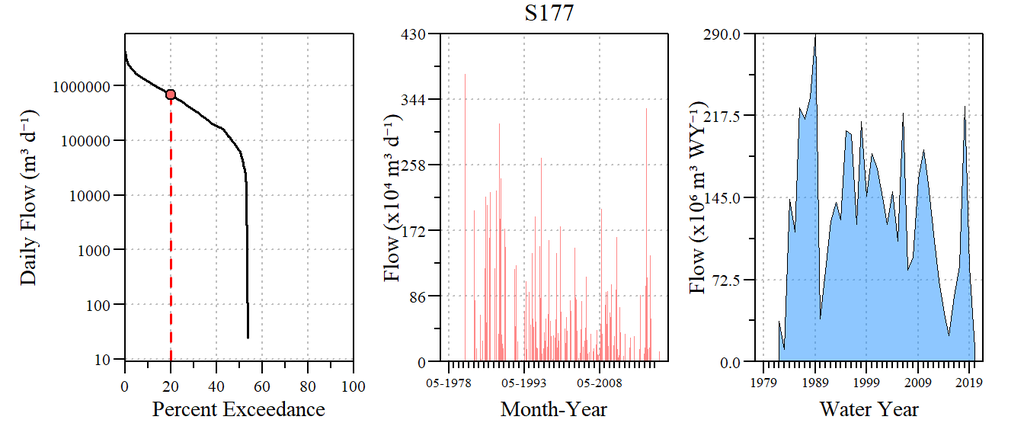

Daily Discharge Data Summary for the Period of Record (Units:m<sup>3</sup> d<sup>-1</sup>)

| SITE | Min | Q1 | Median | Q3 | Max |
| --- | --- | --- | --- | --- | --- |
| S177 | 0 | 0 | 64956.7 | 504851.8 | 4319584 |

Daily Discharge Data Summary for the last 10-WYs (May 2009 - April 2020; Units:m<sup>3</sup> d<sup>-1</sup>)

| SITE | Min | Q1 | Median | Q3 | Max |
| --- | --- | --- | --- | --- | --- |
| S177 | 0 | 0 | 36478.51 | 412958.2 | 3644841 |

Water Year Discharge Data Summary for the Period of Record (Units:m<sup>3</sup> WY<sup>-1</sup>)

| SITE | Min | Q1 | Median | Q3 | Max |
| --- | --- | --- | --- | --- | --- |
| S177 | 11147304 | 82417965 | 125670319 | 185848370 | 290952138 |

Water Year Discharge Data Summary for the last 10-WYs (May 2009 - April 2020; Units:m<sup>3</sup> WY<sup>-1</sup>)

| SITE | Min | Q1 | Median | Q3 | Max |
| --- | --- | --- | --- | --- | --- |
| S177 | 12303777 | 54011783 | 83989208 | 158324125 | 225965077 |

## S178

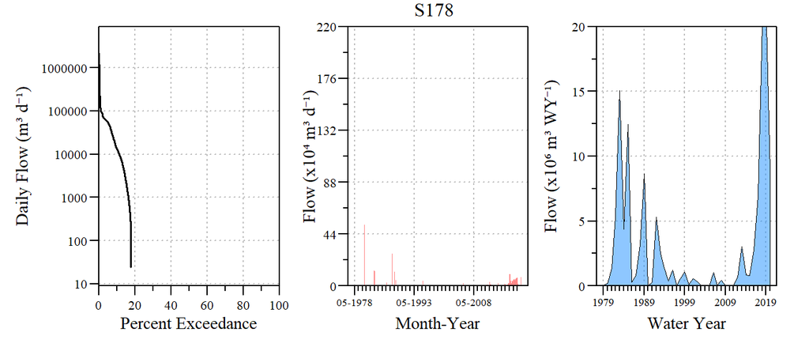

Daily Discharge Data Summary for the Period of Record (Units:m<sup>3</sup> d<sup>-1</sup>)

| SITE | Min | Q1 | Median | Q3 | Max |
| --- | --- | --- | --- | --- | --- |
| S178 | 0 | 0 | 0 | 0 | 2152330 |

Daily Discharge Data Summary for the last 10-WYs (May 2009 - April 2020; Units:m<sup>3</sup> d<sup>-1</sup>)

| SITE | Min | Q1 | Median | Q3 | Max |
| --- | --- | --- | --- | --- | --- |
| S178 | 0 | 0 | 464.8502 | 17040.43 | 286470.1 |

Water Year Discharge Data Summary for the Period of Record (Units:m<sup>3</sup> WY<sup>-1</sup>)

| SITE | Min | Q1 | Median | Q3 | Max |
| --- | --- | --- | --- | --- | --- |
| S178 | 0 | 128518.8 | 805891.2 | 3133592 | 22001654 |

Water Year Discharge Data Summary for the last 10-WYs (May 2009 - April 2020; Units:m<sup>3</sup> WY<sup>-1</sup>)

| SITE | Min | Q1 | Median | Q3 | Max |
| --- | --- | --- | --- | --- | --- |
| S178 | 0 | 490973.6 | 1795606 | 7391259 | 22001654 |

## S18C

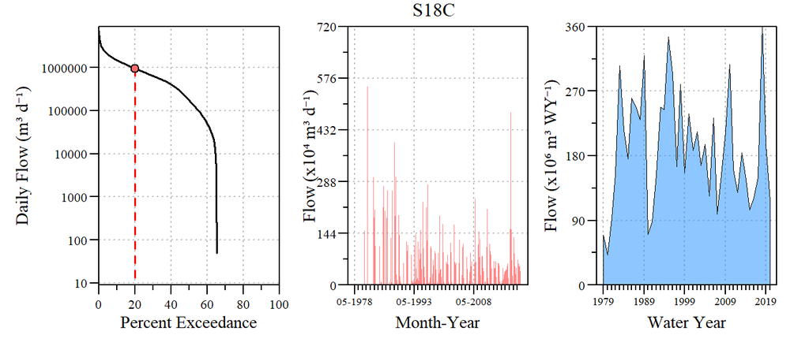

Daily Discharge Data Summary for the Period of Record (Units:m<sup>3</sup> d<sup>-1</sup>)

| SITE | Min | Q1 | Median | Q3 | Max |
| --- | --- | --- | --- | --- | --- |
| S18C | 0 | 0 | 174074.2 | 787798.8 | 7192945 |

Daily Discharge Data Summary for the last 10-WYs (May 2009 - April 2020; Units:m<sup>3</sup> d<sup>-1</sup>)

| SITE | Min | Q1 | Median | Q3 | Max |
| --- | --- | --- | --- | --- | --- |
| S18C | 0 | 31817.77 | 359647.3 | 743784.8 | 5247621 |

Water Year Discharge Data Summary for the Period of Record (Units:m<sup>3</sup> WY<sup>-1</sup>)

| SITE | Min | Q1 | Median | Q3 | Max |
| --- | --- | --- | --- | --- | --- |
| S18C | 41675288 | 133582118 | 179911156 | 242905808 | 363747850 |

Water Year Discharge Data Summary for the last 10-WYs (May 2009 - April 2020; Units:m<sup>3</sup> WY<sup>-1</sup>)

| SITE | Min | Q1 | Median | Q3 | Max |
| --- | --- | --- | --- | --- | --- |
| S18C | 104658967 | 127237280 | 155282414 | 199830880 | 363747850 |

## S197

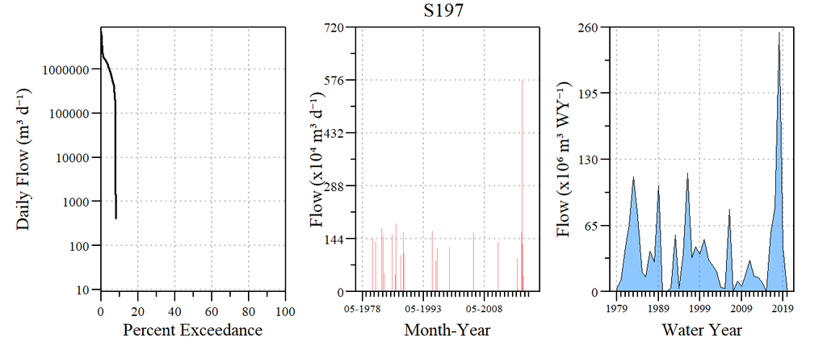

Daily Discharge Data Summary for the Period of Record (Units:m<sup>3</sup> d<sup>-1</sup>)

| SITE | Min | Q1 | Median | Q3 | Max |
| --- | --- | --- | --- | --- | --- |
| S197 | 0 | 0 | 0 | 0 | 7198523 |

Daily Discharge Data Summary for the last 10-WYs (May 2009 - April 2020; Units:m<sup>3</sup> d<sup>-1</sup>)

| SITE | Min | Q1 | Median | Q3 | Max |
| --- | --- | --- | --- | --- | --- |
| S197 | 0 | 0 | 0 | 0 | 6154445 |

Water Year Discharge Data Summary for the Period of Record (Units:m<sup>3</sup> WY<sup>-1</sup>)

| SITE | Min | Q1 | Median | Q3 | Max |
| --- | --- | --- | --- | --- | --- |
| S197 | 0 | 6093348 | 27285055 | 49835764 | 255067513 |

Water Year Discharge Data Summary for the last 10-WYs (May 2009 - April 2020; Units:m<sup>3</sup> WY<sup>-1</sup>)

| SITE | Min | Q1 | Median | Q3 | Max |
| --- | --- | --- | --- | --- | --- |
| S197 | 0 | 7634241 | 16782842 | 46979786 | 255067513 |

# Water Quality Information

Provided in this section are period of record water quality data and summaries of data located in the South Florida Water Management Districts [DBHYDRO](http://my.sfwmd.gov/dbhydroplsql/show_dbkey_info.main_menu). All structure-water quality monitoring location pairings used to construct these water quality time-series can be downloaded below.

Below are a series of plots for each structure with accessible/available data. The data are presented both as individual grab samples (i.e. raw data) and annual flow-weighted mean concentrations based on the Florida Water Year (May 1 - April 30). Water quality data were screened for fatal qualifiers and paired with flow data for each structure with available data. Flow-weighted mean concentrations were calcualted for structures with greater than three samples per year using only positive flow. Similar to the plots above for discharge data, three plots were developed to represent each structure and the associated water quality (total phosphorus). The three plots include (1) the top left plot displaying a percent exceedance curve for all data (solid line) and only flowing conditions (dashed line) based on grab sample (weekly, biweekly or monthly depending on structure); (2) top right plot displays raw grab sample total phosphorus concentration with points color coded relative to flowing conditions (blue: flowing, red: not flowing); (3) bottom plot displays annual flow-weighted mean concentrations and weighted-standard error (FWM ± SE<sub>wtd</sub>). All concentrations are expressed as μg/L (i.e. parts-per-billion).

## S331

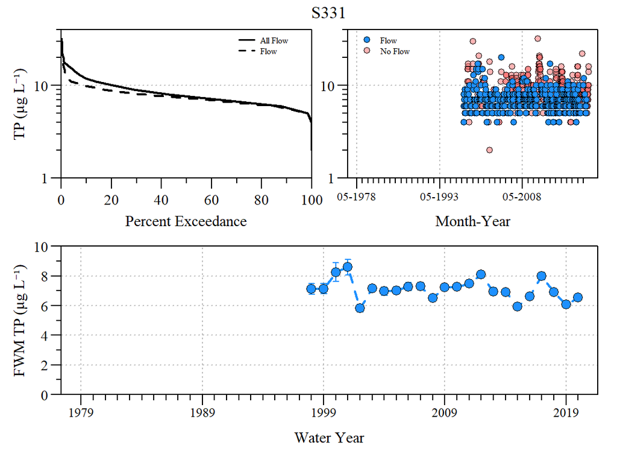

## S173

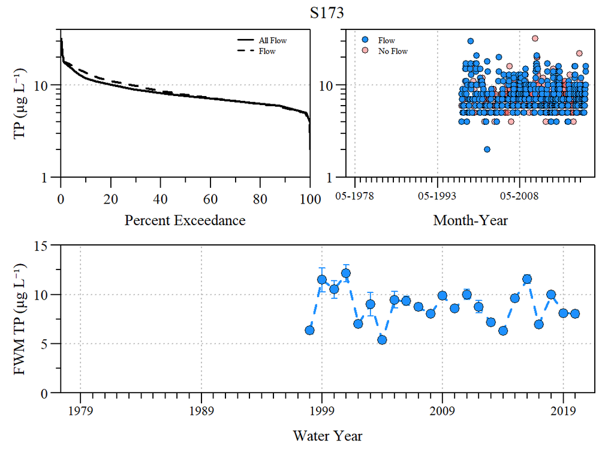

## S357

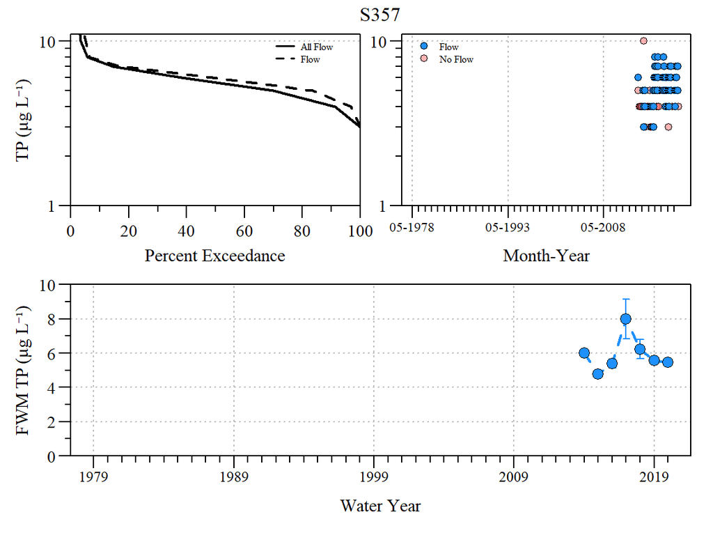

## S332B

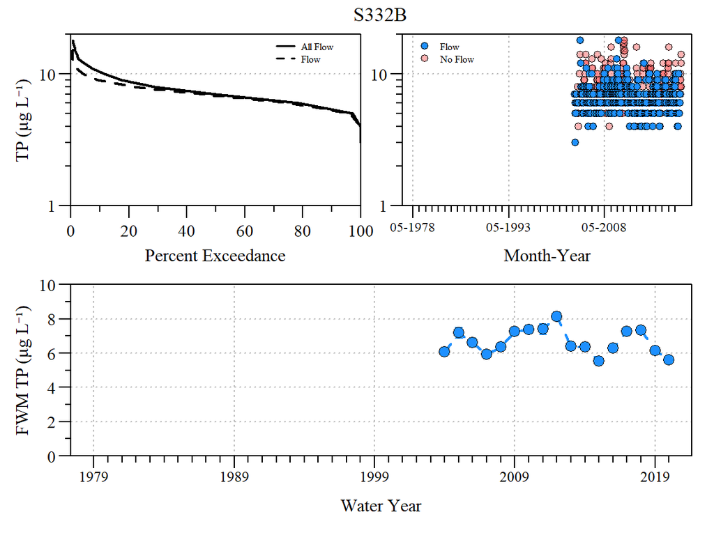

## S332C

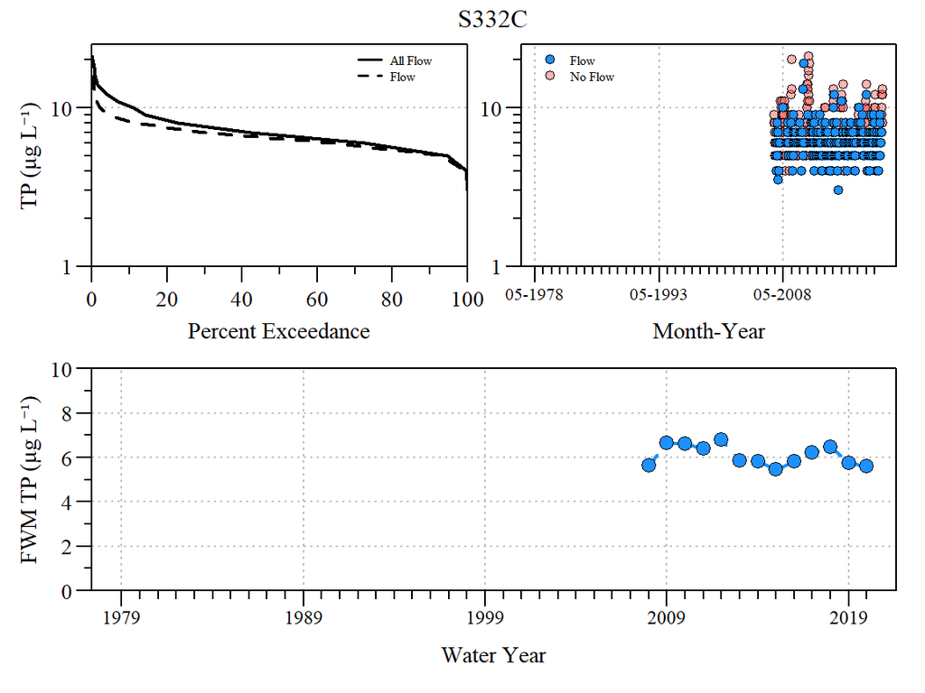

## S174

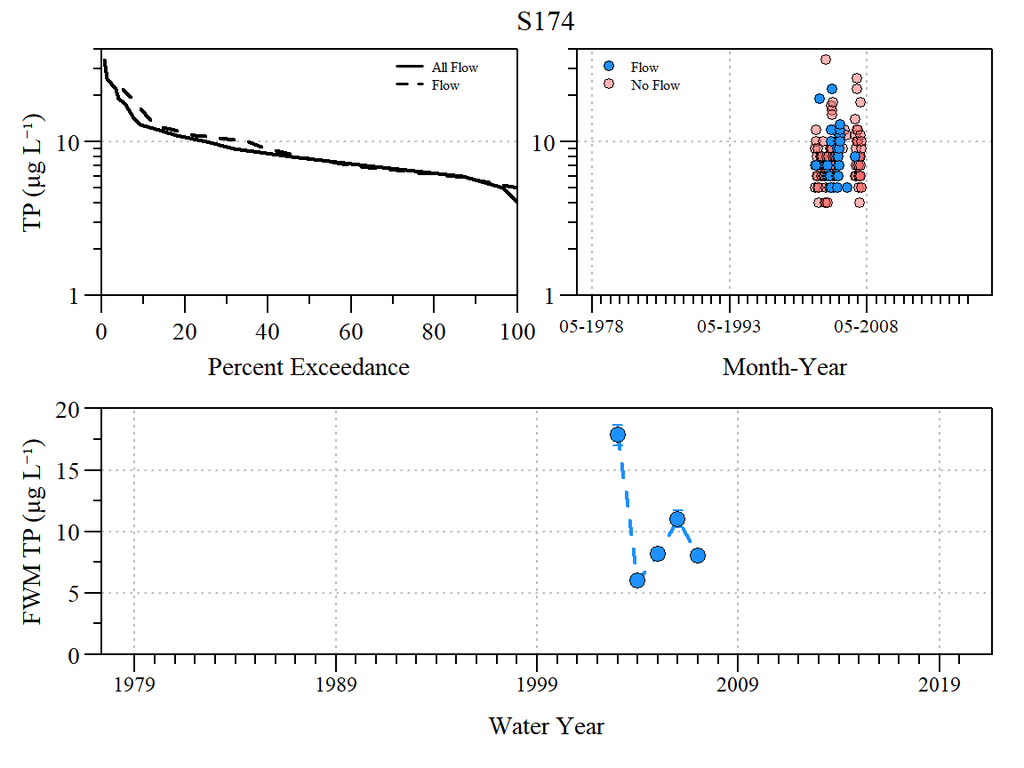

## S332D

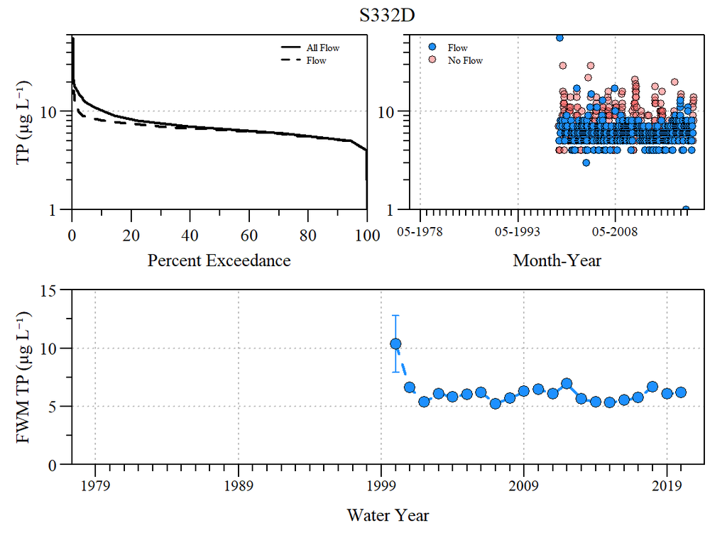

## S328

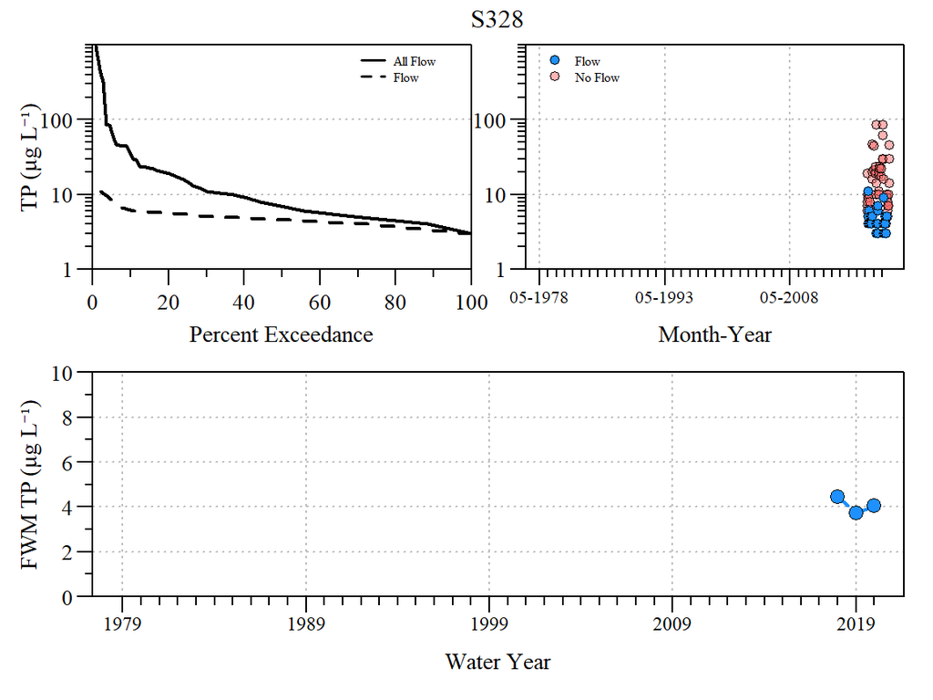

## S332

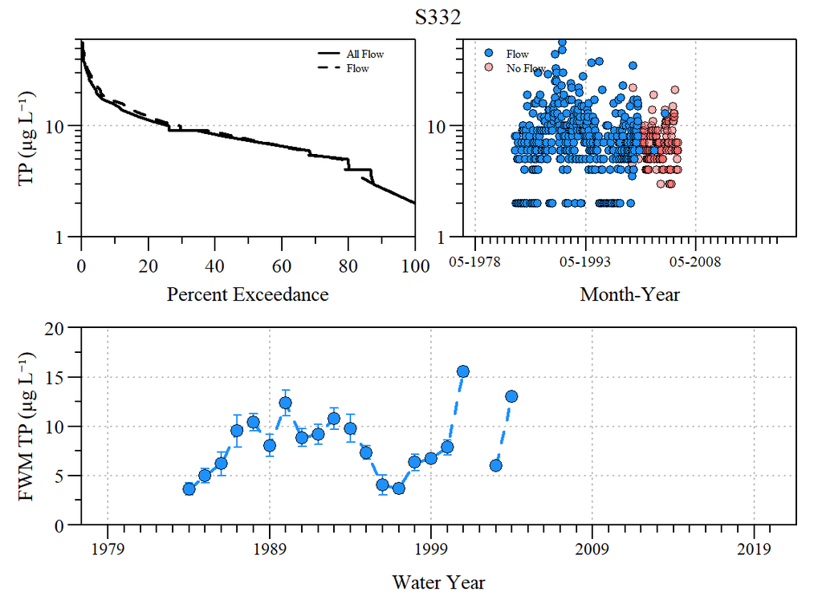

## S176

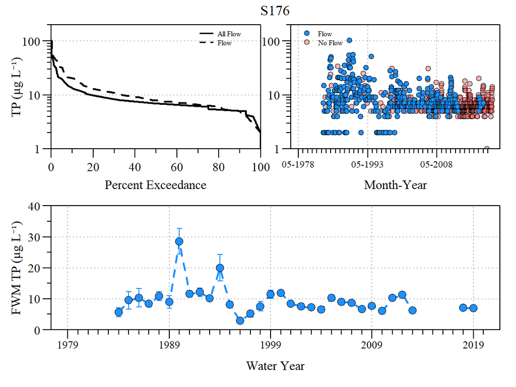

## S200

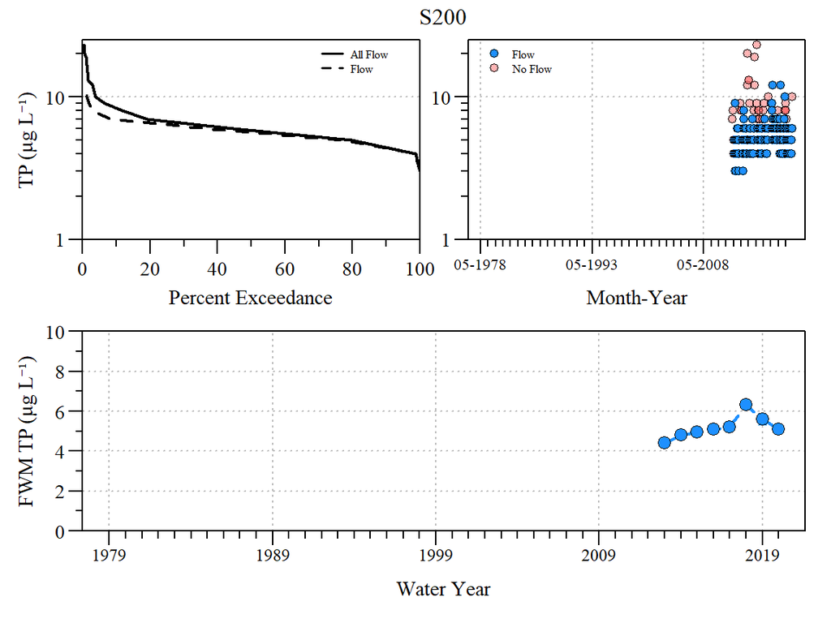

## S332

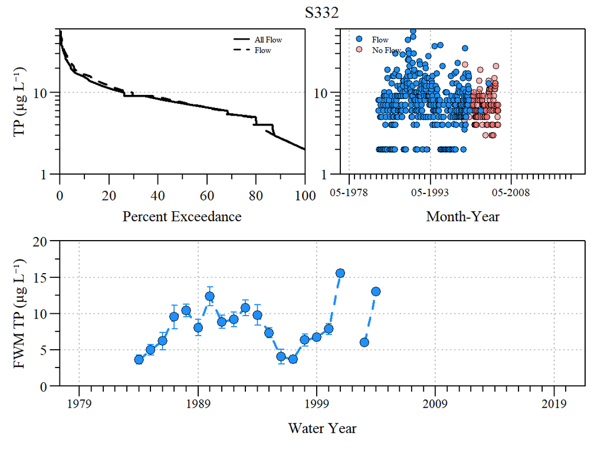